# Ensemble Techniques

David Favela Corella

##Ensemble techniques

Ensemble techniques are those that build up their results based on either previous results or by adding up all results at once. In this case, we take a look into XGBoost and adaboost, which employ boosting as their algorithm. We also use the random forest algorithm. Lastly, we do a simple decision tree to compare the results from all these algorithms and see which one is better.

### Load the data from files

```r
df <- read.csv("bank.csv", header=TRUE)
str(df)
```

```
'data.frame':   10000 obs. of  12 variables:
 $ customer_id     : int  15634602 15647311 15619304 15701354 15737888 15574012 15592531 15656148 15792365 15592389 ...
 $ credit_score    : int  619 608 502 699 850 645 822 376 501 684 ...
 $ country         : chr  "France" "Spain" "France" "France" ...
 $ gender          : int  0 0 0 0 0 1 1 0 1 1 ...
 $ age             : int  42 41 42 39 43 44 50 29 44 27 ...
 $ tenure          : int  2 1 8 1 2 8 7 4 4 2 ...
 $ balance         : num  0 83808 159661 0 125511 ...
 $ products_number : int  1 1 3 2 1 2 2 4 2 1 ...
 $ credit_card     : int  1 0 1 0 1 1 1 1 0 1 ...
 $ active_member   : int  1 1 0 0 1 0 1 0 1 1 ...
 $ estimated_salary: num  101349 112543 113932 93827 79084 ...
 $ churn           : int  1 0 1 0 0 1 0 1 0 0 ...
```

### Data cleaning & Separate data

We only care about four distinct attributes: credit score, gender, estimated salary, and the credit card We transform the gender into F or M, from the binary data provided. We also make sure the credit score and estimated salary remains numeric, while the gender and credit card status become factors.

```r
df <- df[,c(2,4,11,9)]
df$credit_score <- as.numeric(df$credit_score)
df[df$gender == 0,]$gender <- "F"
df[df$gender == 1,]$gender <- "M"
df$gender <- as.factor(df$gender)
df$estimated_salary <- as.numeric(df$estimated_salary)
df$credit_card <- as.factor(df$credit_card)
head(df)
```

|  | credit_score | gender | estimated_salary | credit_card |
| --- | --- | --- | --- | --- |
| 1 | 619 | F | 101348.88 | 1 |
| 2 | 608 | F | 112542.58 | 0 |
| 3 | 502 | F | 113931.57 | 1 |
| 4 | 699 | F | 93826.63 | 0 |
| 5 | 850 | F | 79084.10 | 1 |
| 6 | 645 | M | 149756.71 | 1 |

```r
str(df)
```

```
'data.frame':   10000 obs. of  4 variables:
 $ credit_score    : num  619 608 502 699 850 645 822 376 501 684 ...
 $ gender          : Factor w/ 2 levels "F","M": 1 1 1 1 1 2 2 1 2 2 ...
 $ estimated_salary: num  101349 112543 113932 93827 79084 ...
 $ credit_card     : Factor w/ 2 levels "0","1": 2 1 2 1 2 2 2 2 1 2 ...
```

We run a plot of pairs on the data, dividing the red plots on those without a credit card and those on yellow as the ones with credit cards.

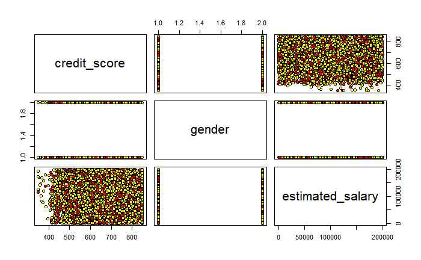

```r
pairs(df[1:3], pch = 21, bg = c("red", "yellow")[unclass(df$credit_card)])
```

On a close up, we can see that when comparing credit score with estimated salary, there seems to be a higher amount of people with credit cards with a credit score of more than 800.

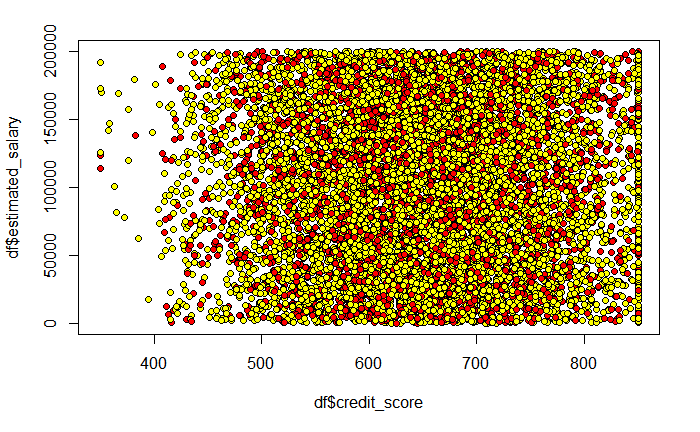

```r
plot(df$credit_score, df$estimated_salary, pch=21, bg=c("red","yellow")
     [unclass(df$credit_card)])
```

Check if there are any missing values on the data.

```r
sapply(df, function(x) sum(is.na(x)==TRUE))
```

```
    credit_score           gender estimated_salary      credit_card
               0                0                0                0
```

## Set the train and test sets for the models

We set the seed and divide the sets into 60/40 for train and test.

```r
set.seed(1234)
i <- sample(1:nrow(df), 0.60*nrow(df), replace=FALSE)
train <- df[i,]
test <- df[-i,]
```

##Logistic Refression on all predictors

We try a simple run on the already known logistic regression model to see how well it performs. As it turns out, it has an accuracy of 0.704, which we’ll use as a baseline.

```r
library(mltools)
glm1 <- glm(credit_card~., data=train, family=binomial)
probs <- predict(glm1, newdata=test, type="response")
pred <- ifelse(probs>0.5, 2, 1)
acc_logreg <- mean(pred==as.integer(test$credit_card))
mcc_logreg <- mcc(pred, as.integer(test$credit_card))
print(paste("accuracy=", acc_logreg))
```

```
[1] "accuracy= 0.70425"
```

```r
print(paste("mcc=", mcc_logreg))
```

```
[1] "mcc= 0"
```

#Random Forest

We run the random forest algorithm. It creates subsets in a tree and has different data in each one of them.

```r
library(randomForest)
set.seed(1234)
rf <- randomForest(credit_card~., data=train, importance=TRUE)
rf
```

```
Call:
 randomForest(formula = credit_card ~ ., data = train, importance = TRUE)
               Type of random forest: classification
                     Number of trees: 500
No. of variables tried at each split: 1

        OOB estimate of  error rate: 29.37%
Confusion matrix:
  0    1 class.error
0 0 1762           1
1 0 4238           0
```

##Testing random forest

Random forest has a accuracy of 0.704, which is acceptable.

```r
pred <- predict(rf, newdata=test, type="response")
acc_rf <- mean(pred==test$credit_card)
mcc_rf <- mcc(factor(pred), test$credit_card)
print(paste("accuracy=", acc_rf))
```

```
[1] "accuracy= 0.70425"
```

```r
print(paste("mcc=", mcc_rf))
```

```
[1] "mcc= 0"
```

##Boosting from adabag library

We use bosoting through adabag.

```r
library(adabag)
```

```r
adab1 <- boosting(credit_card~., data=train, boos=TRUE, mfinal=20, coeflearn='Breiman')
summary(adab1)
```

```
           Length Class   Mode
formula        3  formula call
trees         20  -none-  list
weights       20  -none-  numeric
votes      12000  -none-  numeric
prob       12000  -none-  numeric
class       6000  -none-  character
importance     3  -none-  numeric
terms          3  terms   call
call           6  -none-  call
```

#Testing with adabag

Similar to random forest, we also have an accuracy of 0.704

```r
pred <- predict(adab1, newdata=test, type="response")
acc_adabag <- mean(pred$class==test$credit_card)
mcc_adabag <- mcc(factor(pred$class), test$credit_card)
print(paste("accuracy=", acc_adabag))
```

```
[1] "accuracy= 0.704"
```

```r
print(paste("mcc=", mcc_adabag))
```

```
[1] "mcc= 0.0121854538003118"
```

##XGBoost

Boosting using XGboost.

```r
library(xgboost)
train_label <- ifelse(train$credit_card==1, 1, 0)
train_matrix <- data.matrix(train[, -4])
model <- xgboost(data=train_matrix, label=train_label,
nrounds=100, objective='binary:logistic')
```

#Testing using XGBoost

It had a lower accuracy than previous algorithms.

```r
test_label <- ifelse(test$credit_card==1, 1, 0)
test_matrix <- data.matrix(test[, -4])
probs4 <- predict(model, test_matrix)
pred4 <- ifelse(probs4>0.5, 1, 0)
acc_xg <- mean(pred4==test_label)
mcc_xg <- mcc(pred4, test_label)
print(paste("accuracy=", acc_xg))
```

```
[1] "accuracy= 0.6785"
```

```r
print(paste("mcc=", mcc_xg))
```

```
[1] "mcc= 0.0126338727570966"
```

##Simple Decision Tree Method

```r
library(tree)
```

```r
set.seed(1958)
tree_card <- tree(credit_card~., data=train)
pred <- predict(tree_card, newdata=test, type="class")
table(pred, test$credit_card)
```

```
pred    0    1
   0    0    0
   1 1183 2817
```

#Results

Equal result to adabag and random forest.

```r
mean(pred==test$credit_card)
```

```
[1] 0.70425
```

#Conclusion

All the algorithms performed equally but XGBoost, which was an anomaly. It may have had something to do with how boosting is performed in that model and why it differs from the other ones.